# QM3-GroupWork

J.Larrodé

03/11/2026

# *To what extend do different economic factors affect Renewable Energy Consumption ?*

## Abstract

The study uses Ordinary Least Squares regression to examine the relationship between various economic factors and the use of renewable energy. The multivariable model achieves a slightly higher R-squared than the OLS models however model selection criteria favours the simpler log GDP per capita model. Nevertheless, diagnostic tests indicate that even the preferred model (log GDP) does not fully satisfy the assumptions of the OLS. The findings suggest that higher-income countries tend to have lower renewable energy shares in their final energy consumption, although this relationship should be interpreted cautiously.

## Introduction

The switch to renewable energies is a pressing global concern, given rising temperatures, climate change disasters and geopolitical instability, which all result, directly or indirectly, from reliance on fossil fuels and the consequent release of greenhouse gases (Renewable Energy Institute, 2025).

Thus it is an important endeavour to analyse the factors which affect countries’ disposition to increase their share of renewable energies. This allows policymakers to determine where policy and regulation can act to promote a higher share of renewable energy use. However, drivers of global adoption are varied and the evidence on their effect is mixed (Osińska et al., 2024). Given the scope of this project, economic factors were selected as a focus, as these are well defined and consistently measured across countries. However, it is noted that the true relationships are much more complex and also include a range of social, institutional, cultural and geographical factors (Osińska et al., 2024).

A quick visual inspection of the global distribution of the share of renewable energies in final energy consumption illustrates this complexity.

[figure not shown]

At first glance, this does not clearly show any patterns regarding wealth, which would be expected given the substantial upfront costs of installing renewable energies (International Energy Agency, 2024). However, high-income countries across Europe and North America derive only a minority of their final energy use from renewable sources, while lower-income countries in Central and East Africa report renewable energy shares of up to 100%. This reflects that there are a variety of other factors at play, some of which will be attempted to be laid out in the following.

This project therefore asks:

To what extent are economic factors associated with the share of renewable energy in final energy consumption across countries in 2021?

More specifically, it will be examined how gross domestic product (GDP) per capita, gross capital formation, trade openness, foreign direct investment and natural resource rents are associated with the renewable share of final energy consumption.

World Bank data for 164 countries from the year 2021 is used, as this is the most complete and current global dataset. Relationships are estimated using ordinary least squares (OLS) regression. This is an appropriate choice of method, as the dependent variable (share of renewable energy in final energy use) is continuous and the aim is to estimate the associate of several economic factors with this variable, while holding the others constant, which allows the separate contribution of each factor to be assessed.

## Literature Review & Variable Choice

There has been a substantial amount of research on factors influencing renewable energy consumption (REC), examining financial, political, economic and environmental factors, such as income, energy security, trade, energy prices and regulatory systems (Osińska et al., 2024). However, studies vary considerably with the countries studied, the time period and the method, and thus findings are often inconsistent. For example, it has been shown that trade between EU-15 countries results in an increase in REC, whereas trade openness is negatively correlated with REC in Sub-Saharan Africa (ibid.). Similarly, Osińska et al. (2024), mentions several studies where income has been found to positively impact REC, whereas negative associations have been reported in other studies (Wu et al., 2022). Evidence on international capital flows and resource wealth is similarly divided, with the effects of foreign direct investment and natural resource rents found to vary by sector and type of resource (Doytch & Narayan, 2016; Wang et al., 2023). Given these inconsistencies, this project re-examines a focused set of economic factors, including GDP per capita, gross capital formation, trade openness, foreign direct investment and natural resource rents within a single time frame, across the globe.  
**GDP per capita**

GDP per capita is chosen as the primary measure of a country’s wealth and economic development. This is expected to be closely associated with REC, due to countries’ differing ability to finance the energy transition. Higher-income countries may be more able to raise the necessary money for the high upfront costs of installing renewable energy technology (Ergun & Rivas, 2023). Furthermore, these countries face less pressure to direct public spending towards basic needs, leaving more resources available for investment in energy infrastructure (ibid.). Lastly, once citizen’s basic needs are met, they are more likely to place greater value on environmental issues and are thus more willing to adopt and invest in renewable energy (ibid.).  
Therefore, it would be expected that GDP per capita is positively associated with REC. However, the evidence on this relationship is mixed.  
A heterogeneous panel regression conducted on developed countries concluded that income levels support REC (Shahzad et al., 2021), while an analysis on specifically G7 countries found a negative relationship between economic growth and REC (Wu et al., 2022). In contrast to these linear relationships, a generalised least squares analysis on emerging Asian countries found a U-shaped relationship between GDP per capita and REC (Ergun & Rivas, 2023).  
These findings indicate that a simple linear relationship between income and REC is unlikely across the global sample used. GDP per capita is therefore log-transformed for the following regression analysis, to account for the strong right skew of this data and reduce the influence of wealthy outliers. Subsequent residual diagnostics will determine if the transformed relationship is adequately linear. It is also possible that reverse causality is a possibility, where an increase in renewable energy shares drives economic growth (Osińska et al., 2024). Since the OLS regression cannot separate these directions, the GDP coefficient is interpreted as an association only.

**Gross Capital Formation**  
Gross Capital Formation (as a % of GDP) is used as a measure of a country’s investment rate and, by extension, its capacity to finance renewable energy technology and infrastructure. Specifically, it refers to the expenditure on acquisitions of produced or fixed assets, such as infrastructure and equipment (OECD, 2025). It is expressed as a share of GDP, so that economies of different scales can be compared. Gross capital formation is included because it is expected to impact REC, due to the aforementioned high capital intensity of installing renewable energies (International Energy Agency, 2024). Countries that invest a higher share of their output, are expected to have a more developed infrastructure, which in turn would allow for a quicker adoption of renewable energies. They would also be expected to be better positioned to build new infrastructure for renewable energy adoption (Ergun & Rivas, 2023). However, since this measure captures all forms of investment rather than being energy-specific, it has to be interpreted with caution.  
As with GDP per capita, previous evidence on the effect of this variable on REC is mixed, with a study of Southern African nations suggesting a negative relationship between gross capital formation and REC (Aidoo, 2024), whereas other empirical studies have found a positive effect of gross capital formation on REC (Ergun & Rivas, 2023).

**Natural Resource Rents**  
Total natural resource rents (as a % of GDP) are used as a measure of a country’s natural resource wealth, estimating the value of oil, natural gas, coal, mineral and forest production at world prices, minus the costs of production (World Bank, 2016).  
Natural resource rents are relevant to this analysis due to the apparent “resource curse,” whereby resource-abundant economies tend to grow slower than resource-poor ones (Sachs & Warner, 2001). The same dependence on resource revenues that holds back growth may also slow the energy transition, as revenues from fossil fuels may reduce the incentive to diversify the energy mix and strengthen the position of incumbent energy industries, which would be expected to lower renewable energy consumption. Whether natural resources become a curse depends largely on the quality of a country’s institutions (Mehlum et al., 2006).  
Evidence on the relationship between resource rents and renewable energy consumption is more limited than for the other variables and appears to vary by type of resource. A study analysing global data from 1988 to 2021 found that natural gas and mineral rents weakened renewable energy consumption, whilst oil rents had a positive effect (Wang et al., 2023). This suggests that the components of total resource rents may work in opposite directions, so that a single coefficient could conceal opposing relationships.  
The composition of the measure reinforces this concern. Total natural resource rents combine fossil fuel rents with forest rents, and forest rents rise with fuelwood harvesting. Since traditional biomass such as fuelwood is counted as renewable energy (IEA, 2024), countries with high forest rents may record high renewable shares for reasons unrelated to clean energy investment, which is why Sub-Saharan Africa has the highest renewable share of any region, thus reflecting energy poverty as much as clean energy investment. Results for this variable must therfore be treated as indicative, and disaggregating rents into fossil fuels and forest components would allow this to be tested directly.  
**Foreign Direct Investment**  
Foreign direct investment (FDI) is measured as net inflows as a % of GDP, referring to investment that gives a foreign investor a lasting interest in a domestic enterprise, defined as at least 10% of voting stock, and is compiled from balance-of-payments data (World Bank, 2026).  
FDI is selected as a variable because it is a primary channel through which foreign capital and technology can enter an economy, both of which are required for the transition to renewable energy. Wind and solar installations are capital-intensive, and much of the technical expertise behind them originates from abroad. Countries attracting higher levels of foreign investment may therefore be expected to adopt renewable energy more quickly, as multinationals transfer cleaner technology and management practices to host countries. This is known as the pollution halo hypothesis. By contrast, under the pollution haven hypothesis, firms relocate energy-intensive production to countries with weaker environmental regulation, which would be expected to lower renewable energy consumption (Eskeland & Harrison, 2003).  
Official FDI statistics blur the line between financial and physical investment, with funds channelled through holding companies counted in the same way as investment in factories or energy infrastructure. Damgaard et al. (2019) estimate that almost 40% of global FDI consists of succh investment in corporate shells. Since these flows have little connection to the host country’s actual economy, FDI figures may overstate the foreign capital available for renewable energy; therefore, the measure must be interpreted with caution.  
Previous evidence on the effect of FDI on renewable energy consumption is inconclusive. A study of manufacturing plants in Côte d’Ivoire, Mexico, Morocco and Venezuela found that foreign-owned firms are more energy-efficient and use cleaner types of energy than their domestic counterparts, consistent with the halo hypothesis (Eskeland & Harrison, 2003), whereas a study of 74 countries from 1985-2012 found that FDI tends to increase renewable energy consumption, although the size of the effect varies considerably by sector. In addition, a study of selected ASEAN countries found that FDI and governance quality increase renewable energy, while trade openness reduces it (Huang et al., 2022). Nguyen et al. (2026) identify a conditional halo effect in 50 developing countries: FDI is associated with higher emissions, but this reverses where renewable energy use is higher, suggesting that FDI’s environmental effect depends on the host’s energy mix instead of its volume.  
Since countries expanding their renewable capacity may themselves attract foreign investment, there is the possibility of reverse causality. Because OLS regression cannot distinguish between these directions, the FDI coefficient should only be interpreted as an association.

**Trade Openness**  
Trade (as a % of GDP) is used as a measure of a country’s integration into international markets, referring to the sum of imports and exports of goods and services, and expressed as a share of GDP so that economies of different sizes can be compared (World Bank, 2026).  
Trade openness is expected to affect renewable energy consumption through three channels: the scale of economic activity; the composition of output; and the technology used in production (Grossman & Krueger. 1991). Through the scale effect, greater output raises total energy demand, which may be met largely by fossil fuels. Trade also alters the composition of output, as countries specialise according to their comparative advantage; depending on where that advantage lies, production may shift towards or away from an energy-intensive industry. Finally, openness can change the techniques of production by giving countries easier access to imported renewable energy technology, such as wind turbines and solar panels (Omri & Nguyen, 2014). However, since the ratio is mechanically higher for small re-exporting economies, it partly reflects country size rather than openness alone (Squalli & Wilson, 2011).  
Empirical evidence on trade openness and renewable energy consumption is extensive, but inconsistent. Using system GMM estimation on a panel of 64 countries between 1990 and 2011, Omri & Nguyen (2014) found trade openness to be one of the main drivers of renewable energy consumption. Because this method accounts for the persistence of national energy systems and for unobserved energy characteristics, it offers stronger grounds for inference than a single cross-section. Omri et al. (2015) obtained similar results using pooled OLS, fixed effects and random effects models, suggesting that the finding does not depend on the estimation method. In both studies, the proposed mechanism is technology transfer, whereby open economies gain access to infrastructure such as wind turbines and solar panels, alongside technical expertise.  
More recent studies, however, indicate that the effect of trade depends on a country’s level of development. Covering 186 countries over 1990-2015, Wang & Zhang (2021) found that trade raises renewable energy consumption in high- and upper-middle-income countries, but not in poorer countries, while Zhang et al. (2021) identified a strongly nonlinear relationship across 35 OECD countries. Murshed (2020) reported that greater openness increases the renewable share in low-income countries but reduces it in lower-middle-income economies, and Huag et al. (2022) found a negative effect in selected ASEAN economies, where trade expands energy-intensive industry. Institutions also appear to matter, as trade openness has been found to slow renewable deployment in less democratic countries (Chen et al., 2021). Taken together, these findings suggest that the relationship between renewable energy consumption and trade is unlikely to be uniform across a global sample.

## Step 1 : Loading Data

Before all we need to install the packages needed to conduct our analysis *should that go in the Intro maybe?*

```r
install.packages("readxl")
install.packages("stargazer")
install.packages("ggplot2")
install.packages("performance")
install.packages("gvlma")
```

*“readxl” extracts the data from excel spreadsheets.*  
*“stargazer” and “ggplot2” are used to create plots.*  
*“performance” package allows to use the **model_comparison** R function.*  
*“gvlma” package allows to test linear model fit assumptions*  
We also call their libraries to load the packages.

```r
library(readxl)
library(stargazer)
library(ggplot2)
library(performance)
library(gvlma)
```

Next we import the datasets we have chosen to use for our analysis.  
The following allow us to measure pollution :

```r
Renewable_energies_dataset <- read_excel("Renewable_energies_dataset.xls")
```

While these ones are the different economic factors :

```r
GDP_per_capita_dataset <- read_excel("GDP per capita dataset.xls")
Gross_Capital_Formation_percentage_of_GDP_ <- read_excel("Gross Capital Formation (percentage of GDP).xls")
Urban_population_percentage_of_total_ <- read_excel("Urban population (percentage of total).xls")
Total_natural_resources_rents_of_GDP_ <- read_excel("Total natural resources rents (% of GDP).xls")
Trade_of_GDP_ <- read_excel("Trade (% of GDP).xls")
Foreign_direct_investment<- read_excel("Foreign direct investment, net inflows (% of GDP).xls")
```

Each dataset has data for multiple years. For accuracy we chose to focus on the most recent year with the most amount of data, this proved to be the year of 2021 :

```r
recentdata<-data.frame(Country = Renewable_energies_dataset$`Country Name`,
                       Renewable_energy_consumption = Renewable_energies_dataset$`2021`)
```

```r
recentdata <- within(recentdata, {
              GDP_per_capita = GDP_per_capita_dataset$`2021`
              Gross_Capital  = Gross_Capital_Formation_percentage_of_GDP_$`2021`
              Urban_pop      = Urban_population_percentage_of_total_$`2021`
              Total_natural  = Total_natural_resources_rents_of_GDP_$`2021`
              Trade_GDP      = Trade_of_GDP_$`2021`
              Foreign_direct_investment= Foreign_direct_investment$`2021`
              })
recentdata <-na.omit(recentdata)
```

**Table 1 : Descriptive Statistics

```r
stargazer(recentdata, type="text", digits=1,
          title ="Table 1: Summary Statistics of the Variables (2021)")
```

```
##
## Table 1: Summary Statistics of the Variables (2021)
## ==================================================================
## Statistic                     N    Mean   St. Dev.  Min     Max
## ------------------------------------------------------------------
## Renewable_energy_consumption 164   32.5     26.9    0.0    96.3
## Foreign_direct_investment    164   4.2      6.3    -14.4   37.2
## Trade_GDP                    164   89.3     59.0    4.1    402.5
## Total_natural                164   7.0      10.5    0.0    61.0
## Urban_pop                    164   61.7     21.6   16.5    100.0
## Gross_Capital                164   23.9     8.0    -15.7   44.4
## GDP_per_capita               164 15,425.2 21,534.4 396.0 110,873.1
## ------------------------------------------------------------------
```

[figure not shown]

```r
boxplot(recentdata$Renewable_energy_consumption, main="Renewable Energy Consumption", ylab="Percentage of GDP", col="blue")
```

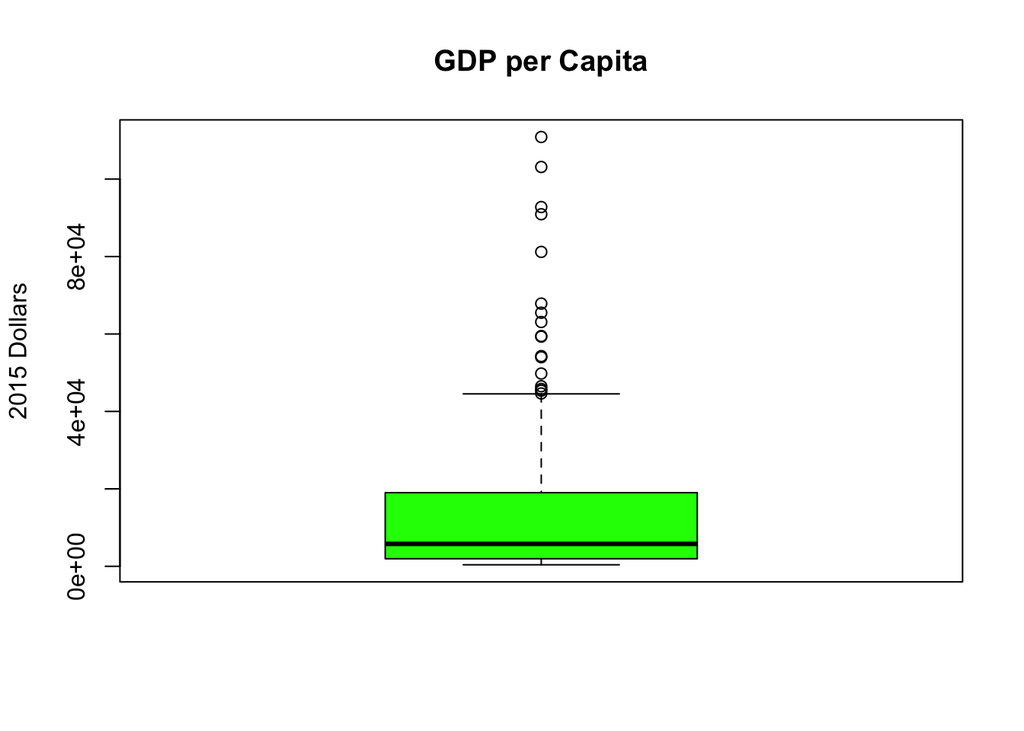

```r
boxplot(recentdata$GDP_per_capita, main="GDP per Capita", ylab="2015 Dollars", col="green")
```

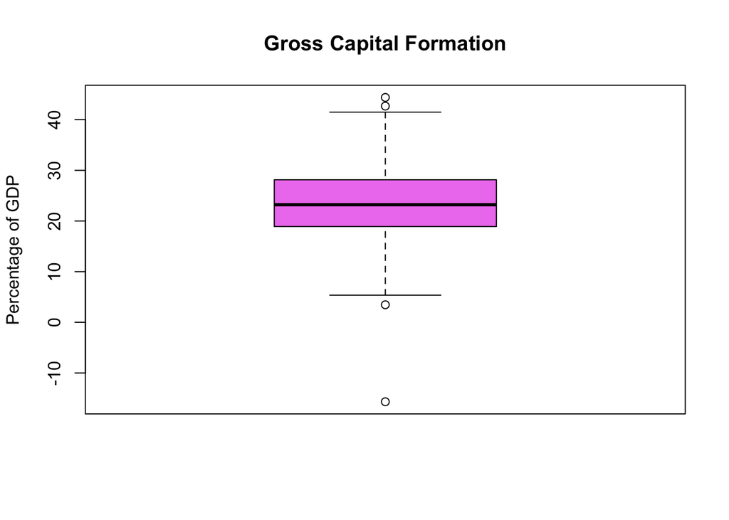

```r
boxplot(recentdata$Gross_Capital, main="Gross Capital Formation", ylab="Percentage of GDP", col="violet")
```

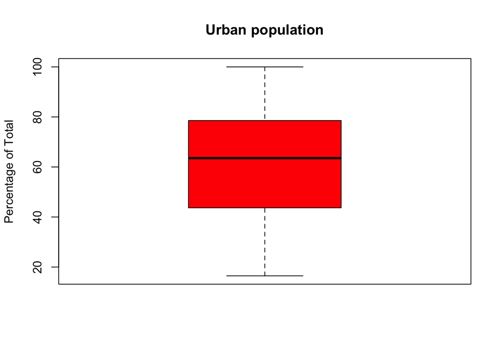

```r
boxplot(recentdata$Urban_pop, main="Urban population", ylab="Percentage of Total", col="red")
```

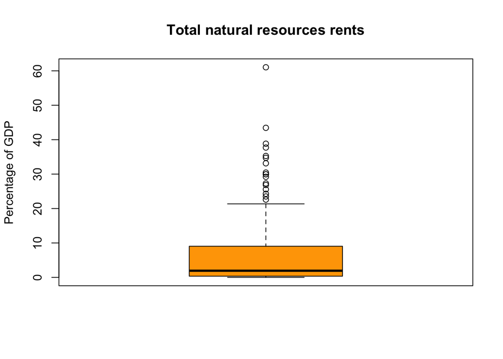

```r
boxplot(recentdata$Total_natural, main="Total natural resources rents", ylab="Percentage of GDP", col="orange")
```

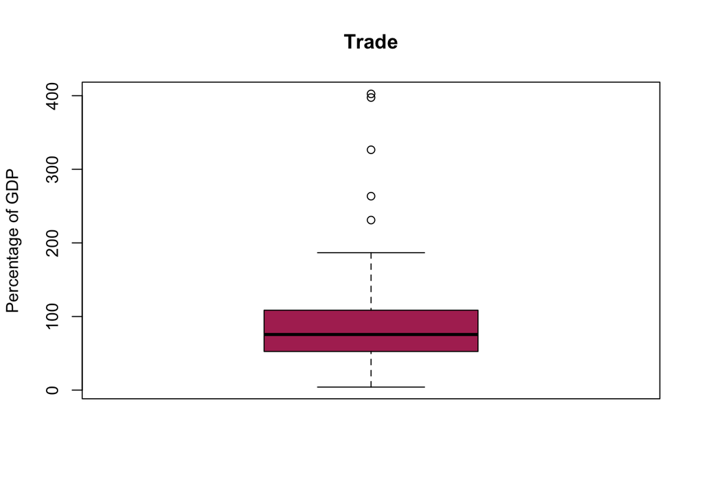

```r
boxplot(recentdata$Trade_GDP, main="Trade", ylab="Percentage of GDP", col="maroon")
```

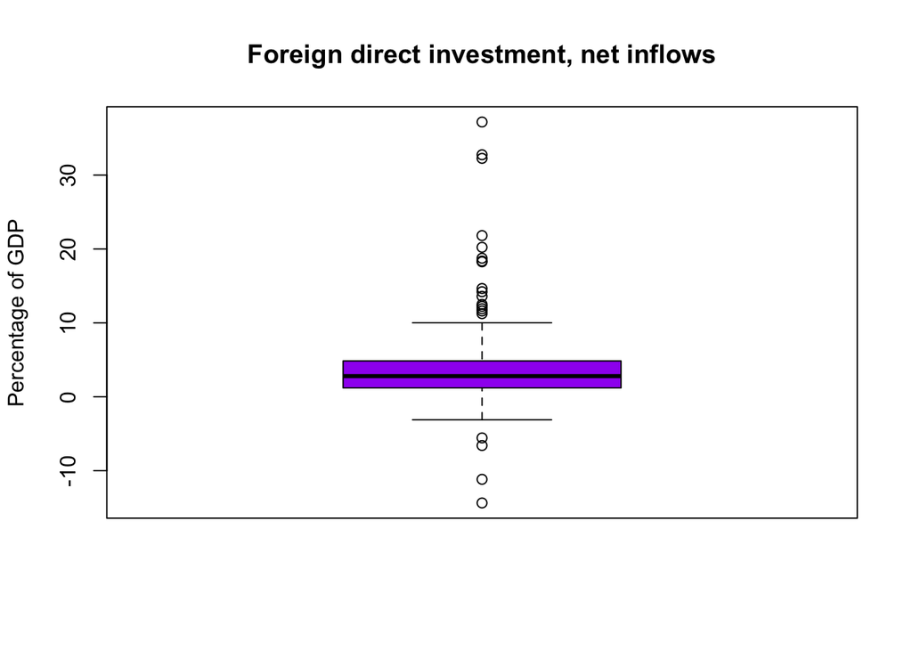

```r
boxplot(recentdata$Foreign_direct_investment, main="Foreign direct investment, net inflows", ylab="Percentage of GDP", col="purple")
```

## Step 2 : Bivariate and Logarithmic OLS

We choose to use the Ordinary Least Squares (OLS) regression because it is considered the Best Linear Unbiased Estimator (BLUE).

First, we look at the relationship between Renewable Energy Consumption and GPD per capita.  
**Table 2 :** OLS results for Renewable Energy Consumption and GDP per capita

```r
mod_gdp <- lm(Renewable_energy_consumption ~ GDP_per_capita, data = recentdata)
stargazer(mod_gdp, type = "text",
          title ="Table 2: OLS results for Renewable Energy Consumption and GDP per capita")
```

```
##
## Table 2: OLS results for Renewable Energy Consumption and GDP per capita
## ================================================
##                         Dependent variable:
##                     ----------------------------
##                     Renewable_energy_consumption
## ------------------------------------------------
## GDP_per_capita               -0.0004***
##                               (0.0001)
##
## Constant                     38.287***
##                               (2.476)
##
## ------------------------------------------------
## Observations                    164
## R2                             0.091
## Adjusted R2                    0.086
## Residual Std. Error      25.755 (df = 162)
## F Statistic           16.246*** (df = 1; 162)
## ================================================
## Note:                *p<0.1; **p<0.05; ***p<0.01
```

**Model Fit**  
It is also important to plot the relationship to visually assess the fit of the model used.  
**Scatter Plot**

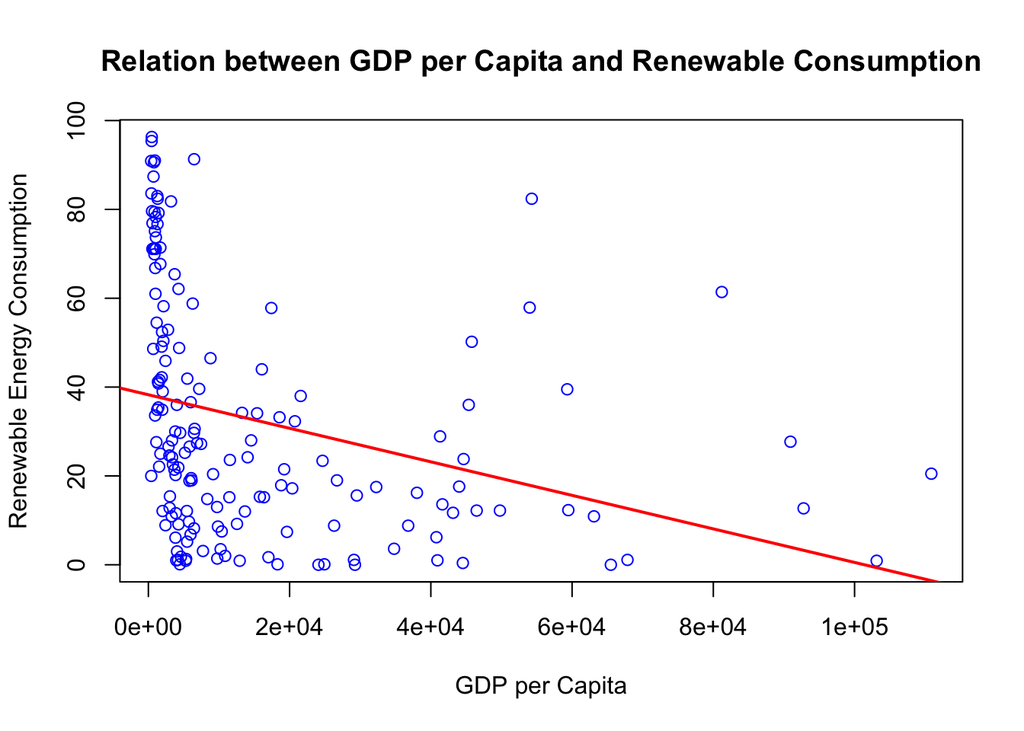

```r
plot(recentdata$GDP_per_capita, recentdata$Renewable_energy_consumption,
     xlab = "GDP per Capita",
     ylab = "Renewable Energy Consumption",
     main = "Relation between GDP per Capita and Renewable Consumption",
     col="blue")
abline(mod_gdp, col="red", lwd=2)
```

In the linear model, most countries are squeezed into the left side of the graph, below about $10,000, while only a few rich countries spread out to the right. Within this small range, the renewable energy share goes all the way from nearly 0% to over 90%, so the straight line cannot show the big change among poorer countries. The line also falls below zero at the highest incomes, which is not possible for a percentage.

Visual assessment is not the most precise so we can check the validation of the linear model assumptions using the R function “gvlma” (Global Validation of Linear Models Assumptions).

```r
gvlma(mod_gdp)
```

```
##
## Call:
## lm(formula = Renewable_energy_consumption ~ GDP_per_capita, data = recentdata)
##
## Coefficients:
##    (Intercept)  GDP_per_capita
##     38.2871271      -0.0003776
##
##
## ASSESSMENT OF THE LINEAR MODEL ASSUMPTIONS
## USING THE GLOBAL TEST ON 4 DEGREES-OF-FREEDOM:
## Level of Significance =  0.05
##
## Call:
##  gvlma(x = mod_gdp)
##
##                     Value   p-value                   Decision
## Global Stat        30.412 4.034e-06 Assumptions NOT satisfied!
## Skewness           11.893 5.636e-04 Assumptions NOT satisfied!
## Kurtosis            2.295 1.298e-01    Assumptions acceptable.
## Link Function      15.072 1.035e-04 Assumptions NOT satisfied!
## Heteroscedasticity  1.152 2.831e-01    Assumptions acceptable.
```

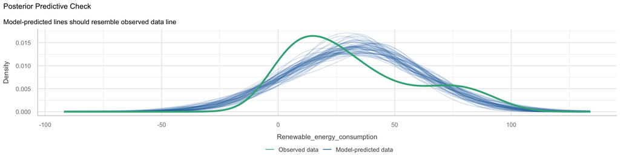

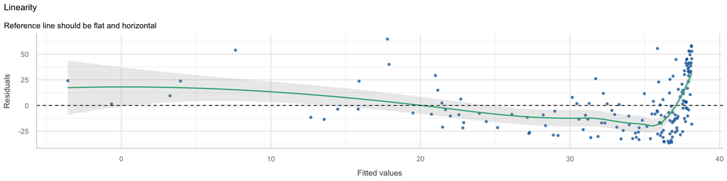

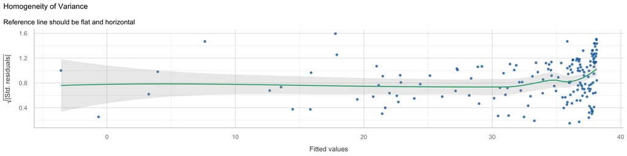

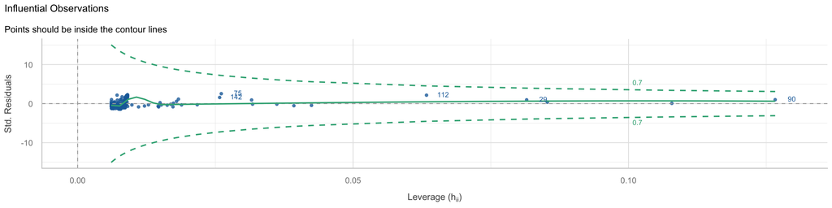

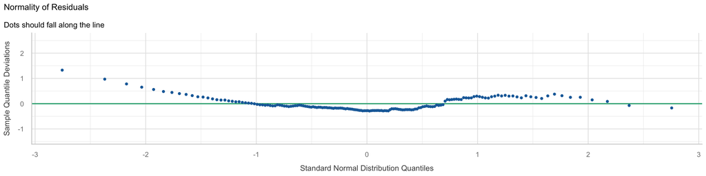

```r
plot(check_model(mod_gdp, panel = FALSE))
```

The global test is highly significant (p-value = 0.000004) which indicates that the model probably does not satisfy the linear model assumptions overall. The skewness test (p-value = 0.000564) and link-function test (p-value = 0.000104) are also significant. This suggests that the **residuals are asymmetric** which indicates that this type of modelling may be inappropriate for this dataset.

We can try using logarithms in the GDP per capita to increase the precision of the model.  
**Table 3 :** OLS results for Renewable Energy Consumption and log(GDP per capita)

```r
mod_log_gdp <- lm(Renewable_energy_consumption ~ log(GDP_per_capita), data =recentdata)
stargazer(mod_log_gdp, type="text",
          title ="Table 3: OLS results for Renewable Energy Consumption and log(GDP per capita)")
```

```
##
## Table 3: OLS results for Renewable Energy Consumption and log(GDP per capita)
## ================================================
##                         Dependent variable:
##                     ----------------------------
##                     Renewable_energy_consumption
## ------------------------------------------------
## log(GDP_per_capita)          -11.063***
##                               (1.196)
##
## Constant                     129.051***
##                               (10.576)
##
## ------------------------------------------------
## Observations                    164
## R2                             0.346
## Adjusted R2                    0.342
## Residual Std. Error      21.851 (df = 162)
## F Statistic           85.629*** (df = 1; 162)
## ================================================
## Note:                *p<0.1; **p<0.05; ***p<0.01
```

Again we can do a visual check with a scatter plot :

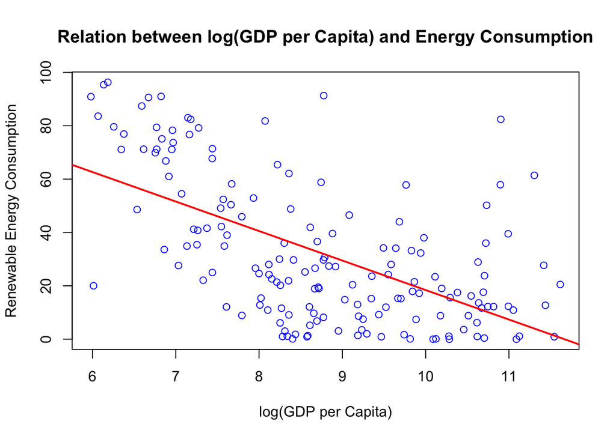

```r
plot(log(recentdata$GDP_per_capita), recentdata$Renewable_energy_consumption,
     xlab = "log(GDP per Capita)",
     ylab = "Renewable Energy Consumption",
     main = "Relation between log(GDP per Capita) and Energy Consumption",
     col="blue")
abline(mod_log_gdp, col="red", lwd=2)
```

After taking the log, the countries are spread out much more evenly, and the downward trend is easier to see. Almost all countries with a renewable energy share above 70% are at the low-income end. However, the points are still widely scattered around the line, and a few rich countries have much higher shares than the model predicts. This matches the model fit results, where the relationship is still not completely linear.

And again, we check the validation of the linear model assumptions to better understand the fit of the model.

```r
gvlma(mod_log_gdp)
```

```
##
## Call:
## lm(formula = Renewable_energy_consumption ~ log(GDP_per_capita),
##     data = recentdata)
##
## Coefficients:
##         (Intercept)  log(GDP_per_capita)
##              129.05               -11.06
##
##
## ASSESSMENT OF THE LINEAR MODEL ASSUMPTIONS
## USING THE GLOBAL TEST ON 4 DEGREES-OF-FREEDOM:
## Level of Significance =  0.05
##
## Call:
##  gvlma(x = mod_log_gdp)
##
##                      Value   p-value                   Decision
## Global Stat        43.1054 9.840e-09 Assumptions NOT satisfied!
## Skewness            7.5122 6.128e-03 Assumptions NOT satisfied!
## Kurtosis            0.0310 8.602e-01    Assumptions acceptable.
## Link Function      35.0150 3.272e-09 Assumptions NOT satisfied!
## Heteroscedasticity  0.5472 4.595e-01    Assumptions acceptable.
```

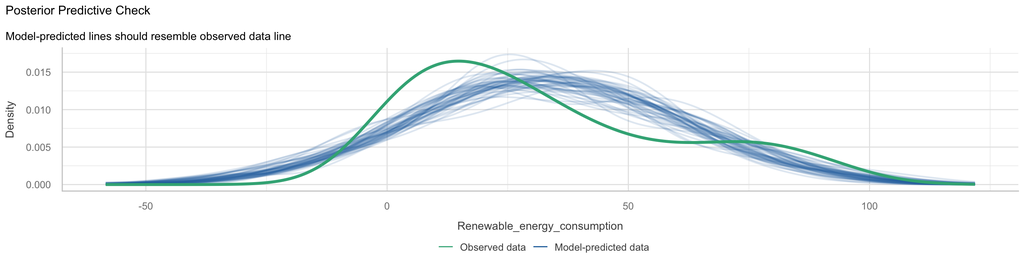

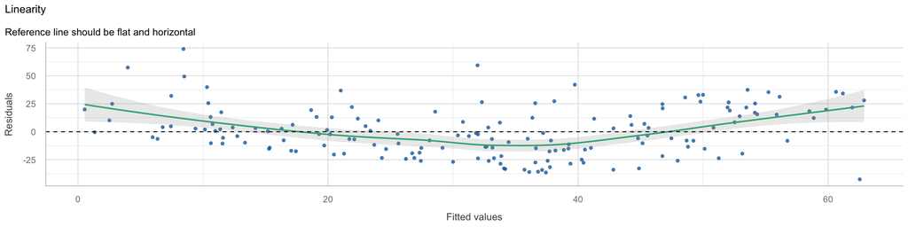

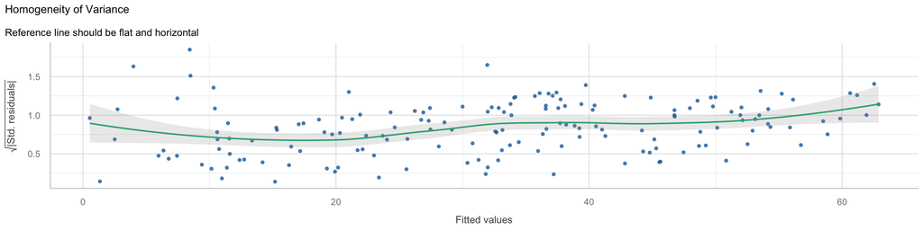

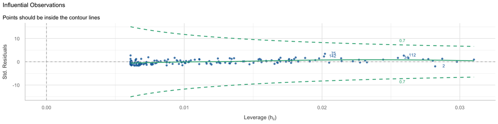

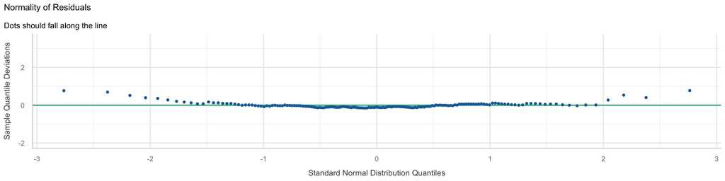

```r
plot(check_model(mod_log_gdp, panel = FALSE))
```

Using the log function highly improves the model’s ability to describe, and clarify the relationship between GDP per capita and usage of renewable energy it does not influence the linear assumptions which remain significantly **unsatisfied**.  
**Renewable Energy Consumption and Gross Capital Formation**  
**Table 4 :** *OLS results for Renewable Energy Consumption and Gross Capital Formation*

```r
mod_gross_capital <- lm(Renewable_energy_consumption ~ Gross_Capital, data = recentdata)
stargazer(mod_gross_capital, type="text",
          title ="Table 4: OLS results for Renewable Energy Consumption and Gross Capital Formation")
```

```
##
## Table 4: OLS results for Renewable Energy Consumption and Gross Capital Formation
## ================================================
##                         Dependent variable:
##                     ----------------------------
##                     Renewable_energy_consumption
## ------------------------------------------------
## Gross_Capital                  -0.060
##                               (0.263)
##
## Constant                     33.890***
##                               (6.627)
##
## ------------------------------------------------
## Observations                    164
## R2                             0.0003
## Adjusted R2                    -0.006
## Residual Std. Error      27.011 (df = 162)
## F Statistic             0.052 (df = 1; 162)
## ================================================
## Note:                *p<0.1; **p<0.05; ***p<0.01
```

We can also do a visual check to understand why it isn’t significant.

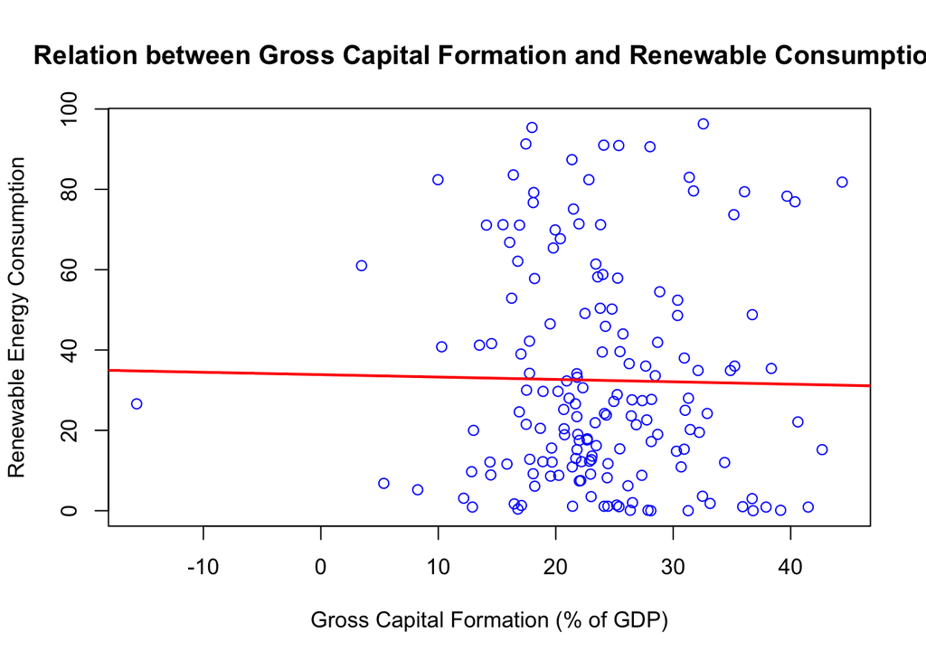

```r
plot(recentdata$Gross_Capital, recentdata$Renewable_energy_consumption,
     xlab = "Gross Capital Formation (% of GDP)",
     ylab = "Renewable Energy Consumption",
     main = "Relation between Gross Capital Formation and Renewable Consumption",
     col="blue")
abline(mod_gross_capital, col="red", lwd=2)
```

The regression line is almost flat. At every level of investment, from about 10% to 40% of GDP, the renewable energy share ranges from nearly 0% to over 90%, so there is no clear pattern. There is also one outlier with negative gross capital formation (around −15.7%).

**Model Fit**

```r
gvlma(mod_gross_capital)
```

```
##
## Call:
## lm(formula = Renewable_energy_consumption ~ Gross_Capital, data = recentdata)
##
## Coefficients:
##   (Intercept)  Gross_Capital
##      33.89047       -0.05985
##
##
## ASSESSMENT OF THE LINEAR MODEL ASSUMPTIONS
## USING THE GLOBAL TEST ON 4 DEGREES-OF-FREEDOM:
## Level of Significance =  0.05
##
## Call:
##  gvlma(x = mod_gross_capital)
##
##                       Value   p-value                   Decision
## Global Stat        18.31873 1.069e-03 Assumptions NOT satisfied!
## Skewness           15.37908 8.796e-05 Assumptions NOT satisfied!
## Kurtosis            2.19846 1.381e-01    Assumptions acceptable.
## Link Function       0.02123 8.841e-01    Assumptions acceptable.
## Heteroscedasticity  0.71996 3.962e-01    Assumptions acceptable.
```

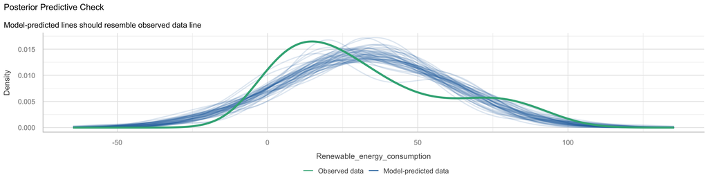

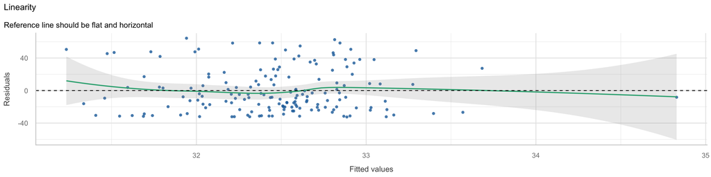

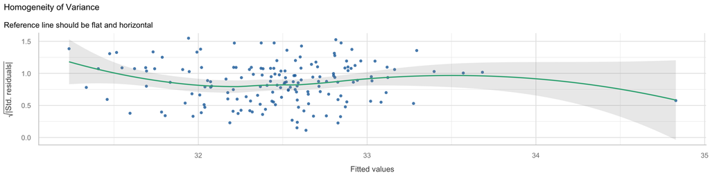

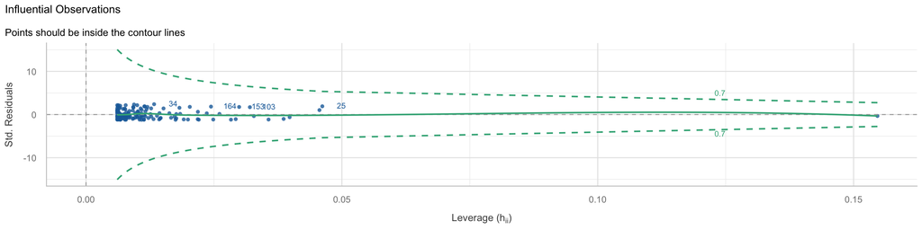

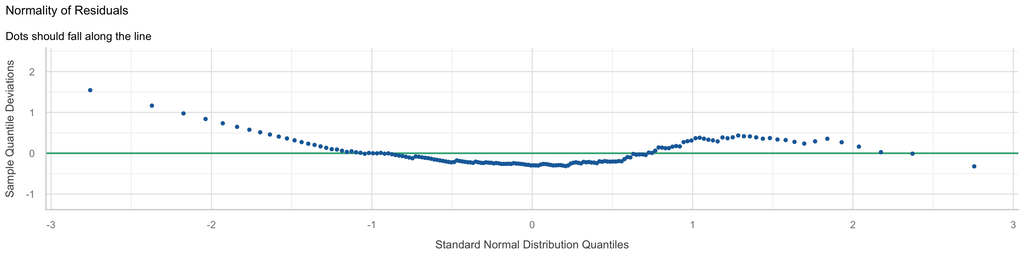

```r
plot(check_model(mod_gross_capital, panel = FALSE))
```

The skewness test is significant (p-value = 0.000088), indicating a problem with the symmetry of the residual distribution. However, the kurtosis (p-value = 0.138), link-function (p-value = 0.884) and heteroscedasticity (p-value = 0.396) tests are not significant. This means that **skewness** is the main issue identified by the individual tests.  
**Renewable Energy Consumption and Urban Population**  
**Table 5 :** *OLS results for Renewable Energy Consumption and Urban Population*

```r
mod_urban_pop <- lm(Renewable_energy_consumption ~ Urban_pop, data = recentdata)
stargazer(mod_urban_pop, type="text",
          title ="Table 5: OLS results for Renewable Energy Consumption and Urban Population")
```

```
##
## Table 5: OLS results for Renewable Energy Consumption and Urban Population
## ================================================
##                         Dependent variable:
##                     ----------------------------
##                     Renewable_energy_consumption
## ------------------------------------------------
## Urban_pop                    -0.605***
##                               (0.086)
##
## Constant                     69.804***
##                               (5.602)
##
## ------------------------------------------------
## Observations                    164
## R2                             0.235
## Adjusted R2                    0.231
## Residual Std. Error      23.625 (df = 162)
## F Statistic           49.832*** (df = 1; 162)
## ================================================
## Note:                *p<0.1; **p<0.05; ***p<0.01
```

**Scatter Plot**

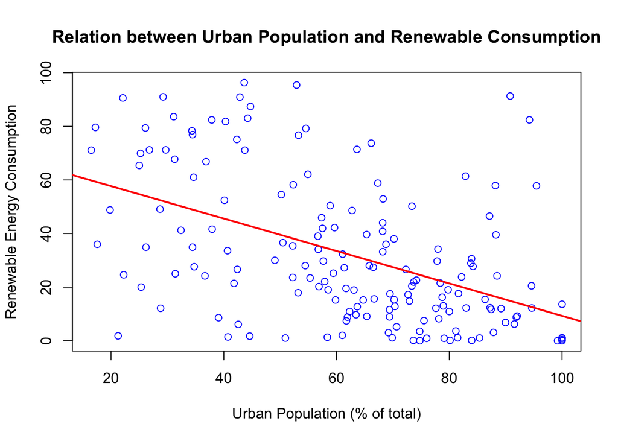

```r
plot(recentdata$Urban_pop, recentdata$Renewable_energy_consumption,
     xlab = "Urban Population (% of total)",
     ylab = "Renewable Energy Consumption",
     main = "Relation between Urban Population and Renewable Consumption",
     col="blue")
abline(mod_urban_pop, col="red", lwd=2)
```

The scatter plot shows a downward trend, but the points are widely spread. Countries with low urbanisation have very different renewable energy shares, from almost 0% to over 90%, while countries that are close to 100% urban mostly have shares near zero.

**Model Fit**

```r
gvlma(mod_urban_pop)
```

```
##
## Call:
## lm(formula = Renewable_energy_consumption ~ Urban_pop, data = recentdata)
##
## Coefficients:
## (Intercept)    Urban_pop
##     69.8036      -0.6052
##
##
## ASSESSMENT OF THE LINEAR MODEL ASSUMPTIONS
## USING THE GLOBAL TEST ON 4 DEGREES-OF-FREEDOM:
## Level of Significance =  0.05
##
## Call:
##  gvlma(x = mod_urban_pop)
##
##                      Value   p-value                   Decision
## Global Stat        14.8156 0.0050993 Assumptions NOT satisfied!
## Skewness           11.5812 0.0006662 Assumptions NOT satisfied!
## Kurtosis            0.4609 0.4971822    Assumptions acceptable.
## Link Function       0.8732 0.3500732    Assumptions acceptable.
## Heteroscedasticity  1.9003 0.1680497    Assumptions acceptable.
```

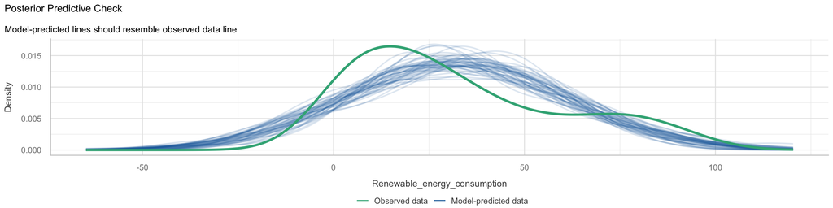

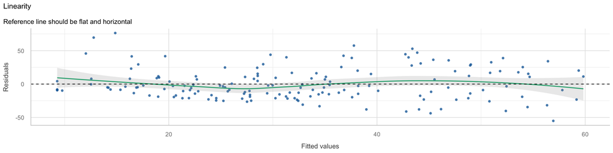

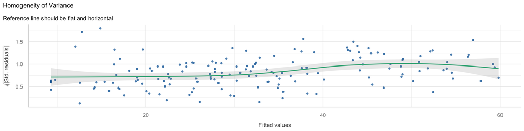

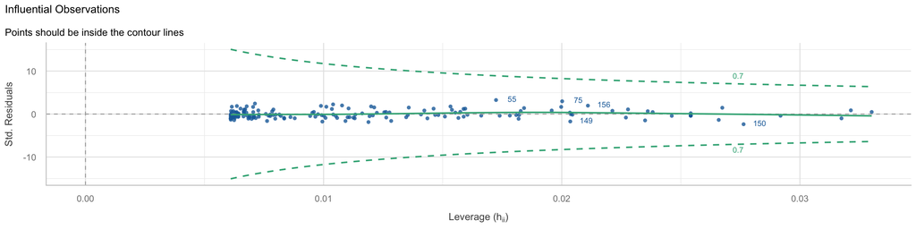

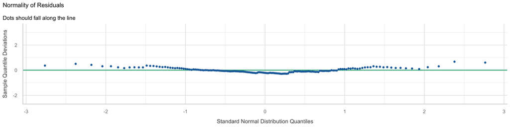

```r
plot(check_model(mod_urban_pop, panel = FALSE))
```

The skewness test is significant (p-value = 0.000666), suggesting asymmetric residuals like the previous instance. In contrast, heteroscedasticity (p-value = 0.168) are all acceptable at the 5% level. Therefore, the main issue identified by the function is **residual skewness** rather than heteroscedasticity.